# STA 2040 END SEMESTER EXAMINATIONS

Ivy Kemunto

2023-06-02

# TASK 1: Load and Understand the Data

## - Use the proper library to load the dataset into RStudio

```r
library(readr)
student_mat <- read_csv("C:/Users/ADMIN/Desktop/End-semesters STA 2040/student-mat.csv")
View(student_mat)
```

-Here I loaded and viewed the data set to get the initial and basic understanding of its structure and contents. -I noted that the data set has 395 entries and 33 total columns

## - To gain a general sense of the dataset, display summary statistics.

```r
# GENERATING THE DATASET DESCRIPTIONS AND SUMMARY STATISTICS
# Getting the shape of the dataset
shape=dim(student_mat)
shape
```

```
## [1] 395  33
```

```r
# Get the column names of the dataset
column_names=colnames(student_mat)
print(column_names)
```

```
##  [1] "school"     "sex"        "age"        "address"    "famsize"
##  [6] "Pstatus"    "Medu"       "Fedu"       "Mjob"       "Fjob"
## [11] "reason"     "guardian"   "traveltime" "studytime"  "failures"
## [16] "schoolsup"  "famsup"     "paid"       "activities" "nursery"
## [21] "higher"     "internet"   "romantic"   "famrel"     "freetime"
## [26] "goout"      "Dalc"       "Walc"       "health"     "absences"
## [31] "G1"         "G2"         "G3"
```

```r
# Summary of numeric columns
summary(student_mat[c("age", "absences", "G1", "G2", "G3","Medu", "Fedu", "traveltime", "studytime", "failures", "famrel","freetime", "goout", "Dalc", "Walc", "health")])
```

```
##       age          absences            G1              G2
##  Min.   :15.0   Min.   : 0.000   Min.   : 3.00   Min.   : 0.00
##  1st Qu.:16.0   1st Qu.: 0.000   1st Qu.: 8.00   1st Qu.: 9.00
##  Median :17.0   Median : 4.000   Median :11.00   Median :11.00
##  Mean   :16.7   Mean   : 5.709   Mean   :10.91   Mean   :10.71
##  3rd Qu.:18.0   3rd Qu.: 8.000   3rd Qu.:13.00   3rd Qu.:13.00
##  Max.   :22.0   Max.   :75.000   Max.   :19.00   Max.   :19.00
##        G3             Medu            Fedu         traveltime
##  Min.   : 0.00   Min.   :0.000   Min.   :0.000   Min.   :1.000
##  1st Qu.: 8.00   1st Qu.:2.000   1st Qu.:2.000   1st Qu.:1.000
##  Median :11.00   Median :3.000   Median :2.000   Median :1.000
##  Mean   :10.42   Mean   :2.749   Mean   :2.522   Mean   :1.448
##  3rd Qu.:14.00   3rd Qu.:4.000   3rd Qu.:3.000   3rd Qu.:2.000
##  Max.   :20.00   Max.   :4.000   Max.   :4.000   Max.   :4.000
##    studytime        failures          famrel         freetime
##  Min.   :1.000   Min.   :0.0000   Min.   :1.000   Min.   :1.000
##  1st Qu.:1.000   1st Qu.:0.0000   1st Qu.:4.000   1st Qu.:3.000
##  Median :2.000   Median :0.0000   Median :4.000   Median :3.000
##  Mean   :2.035   Mean   :0.3342   Mean   :3.944   Mean   :3.235
##  3rd Qu.:2.000   3rd Qu.:0.0000   3rd Qu.:5.000   3rd Qu.:4.000
##  Max.   :4.000   Max.   :3.0000   Max.   :5.000   Max.   :5.000
##      goout            Dalc            Walc           health
##  Min.   :1.000   Min.   :1.000   Min.   :1.000   Min.   :1.000
##  1st Qu.:2.000   1st Qu.:1.000   1st Qu.:1.000   1st Qu.:3.000
##  Median :3.000   Median :1.000   Median :2.000   Median :4.000
##  Mean   :3.109   Mean   :1.481   Mean   :2.291   Mean   :3.554
##  3rd Qu.:4.000   3rd Qu.:2.000   3rd Qu.:3.000   3rd Qu.:5.000
##  Max.   :5.000   Max.   :5.000   Max.   :5.000   Max.   :5.000
```

```r
# Generate the structure of the dataset
str(student_mat)
```

```
## spc_tbl_ [395 × 33] (S3: spec_tbl_df/tbl_df/tbl/data.frame)
##  $ school    : chr [1:395] "GP" "GP" "GP" "GP" ...
##  $ sex       : chr [1:395] "F" "F" "F" "M" ...
##  $ age       : num [1:395] 17 15 16 16 16 15 15 15 15 15 ...
##  $ address   : chr [1:395] "U" "U" "U" "U" ...
##  $ famsize   : chr [1:395] "GT3" "GT3" "GT3" "LE3" ...
##  $ Pstatus   : chr [1:395] "T" "T" "T" "T" ...
##  $ Medu      : num [1:395] 1 4 3 4 2 3 3 4 2 4 ...
##  $ Fedu      : num [1:395] 1 2 3 3 2 2 4 4 1 4 ...
##  $ Mjob      : chr [1:395] "at_home" "health" "other" "services" ...
##  $ Fjob      : chr [1:395] "other" "services" "other" "other" ...
##  $ reason    : chr [1:395] "course" "home" "home" "reputation" ...
##  $ guardian  : chr [1:395] "father" "mother" "father" "mother" ...
##  $ traveltime: num [1:395] 1 1 1 1 1 1 1 1 3 1 ...
##  $ studytime : num [1:395] 2 3 2 2 2 2 2 2 3 1 ...
##  $ failures  : num [1:395] 0 0 0 0 0 0 0 0 0 0 ...
##  $ schoolsup : chr [1:395] "no" "no" "no" "no" ...
##  $ famsup    : chr [1:395] "yes" "yes" "yes" "yes" ...
##  $ paid      : chr [1:395] "no" "yes" "yes" "yes" ...
##  $ activities: chr [1:395] "no" "yes" "no" "yes" ...
##  $ nursery   : chr [1:395] "no" "yes" "yes" "yes" ...
##  $ higher    : chr [1:395] "yes" "yes" "yes" "yes" ...
##  $ internet  : chr [1:395] "yes" "yes" "no" "yes" ...
##  $ romantic  : chr [1:395] "no" "yes" "no" "no" ...
##  $ famrel    : num [1:395] 5 3 4 5 4 4 5 3 5 4 ...
##  $ freetime  : num [1:395] 3 2 3 4 4 2 5 3 2 3 ...
##  $ goout     : num [1:395] 3 2 2 2 4 2 1 3 2 3 ...
##  $ Dalc      : num [1:395] 1 1 1 1 1 1 1 1 1 1 ...
##  $ Walc      : num [1:395] 1 1 2 2 1 1 1 2 1 3 ...
##  $ health    : num [1:395] 3 5 5 5 3 1 5 2 4 5 ...
##  $ absences  : num [1:395] 4 2 4 10 0 0 0 0 4 2 ...
##  $ G1        : num [1:395] 5 15 6 15 12 16 14 10 10 14 ...
##  $ G2        : num [1:395] 5 14 10 15 12 18 15 8 12 14 ...
##  $ G3        : num [1:395] 6 15 10 15 11 19 15 9 12 14 ...
##  - attr(*, "spec")=
##   .. cols(
##   ..   school = col_character(),
##   ..   sex = col_character(),
##   ..   age = col_double(),
##   ..   address = col_character(),
```

[output cut: 16 more lines]

```
##   ..   higher = col_character(),
##   ..   internet = col_character(),
##   ..   romantic = col_character(),
##   ..   famrel = col_double(),
##   ..   freetime = col_double(),
##   ..   goout = col_double(),
##   ..   Dalc = col_double(),
##   ..   Walc = col_double(),
##   ..   health = col_double(),
##   ..   absences = col_double(),
##   ..   G1 = col_double(),
##   ..   G2 = col_double(),
##   ..   G3 = col_double()
##   .. )
##  - attr(*, "problems")=<externalptr>
```

```r
# Previewing the first few rows of the dataset
head(student_mat)
```

```
## # A tibble: 6 × 33
##   school sex     age address famsize Pstatus  Medu  Fedu Mjob     Fjob    reason
##   <chr>  <chr> <dbl> <chr>   <chr>   <chr>   <dbl> <dbl> <chr>    <chr>   <chr>
## 1 GP     F        17 U       GT3     T           1     1 at_home  other   course
## 2 GP     F        15 U       GT3     T           4     2 health   servic… home
## 3 GP     F        16 U       GT3     T           3     3 other    other   home
## 4 GP     M        16 U       LE3     T           4     3 services other   reput…
## 5 GP     M        16 U       LE3     T           2     2 other    other   home
## 6 GP     M        15 U       LE3     A           3     2 services other   home
## # ℹ 22 more variables: guardian <chr>, traveltime <dbl>, studytime <dbl>,
## #   failures <dbl>, schoolsup <chr>, famsup <chr>, paid <chr>,
## #   activities <chr>, nursery <chr>, higher <chr>, internet <chr>,
## #   romantic <chr>, famrel <dbl>, freetime <dbl>, goout <dbl>, Dalc <dbl>,
## #   Walc <dbl>, health <dbl>, absences <dbl>, G1 <dbl>, G2 <dbl>, G3 <dbl>
```

```r
# Previewing the last few rows of the dataset
tail(student_mat)
```

```
## # A tibble: 6 × 33
##   school sex     age address famsize Pstatus  Medu  Fedu Mjob     Fjob    reason
##   <chr>  <chr> <dbl> <chr>   <chr>   <chr>   <dbl> <dbl> <chr>    <chr>   <chr>
## 1 GP     M        17 U       GT3     T           4     4 teacher  teacher reput…
## 2 GP     M        16 U       GT3     T           3     3 at_home  other   reput…
## 3 GP     F        17 U       LE3     T           2     2 services other   course
## 4 GP     F        18 U       GT3     T           4     4 health   health  reput…
## 5 GP     F        18 U       GT3     T           1     1 other    other   home
## 6 GP     F        19 U       LE3     T           1     1 at_home  other   reput…
## # ℹ 22 more variables: guardian <chr>, traveltime <dbl>, studytime <dbl>,
## #   failures <dbl>, schoolsup <chr>, famsup <chr>, paid <chr>,
## #   activities <chr>, nursery <chr>, higher <chr>, internet <chr>,
## #   romantic <chr>, famrel <dbl>, freetime <dbl>, goout <dbl>, Dalc <dbl>,
## #   Walc <dbl>, health <dbl>, absences <dbl>, G1 <dbl>, G2 <dbl>, G3 <dbl>
```

```r
# Check the class of the dataset
class(student_mat)
```

```
## [1] "spec_tbl_df" "tbl_df"      "tbl"         "data.frame"
```

```r
# Get the attributes of the data frame
attributes(student_mat)
```

[output not shown]

[output cut: 25 more lines]

**Shape of the Data set:**

The shape variable stores the dimensions of the dataset. It indicates that the dataset contains 395 rows and 33 columns. This means there are data entries for 395 students, each described by 33 attributes.

**Column Names:**

The column_names variable holds the names of all 33 columns in the data set. These column names correspond to different characteristics and information about the students: The columns are as follows( I got the meaning of the columns after some research on Kaggle):

1. **school (Character):** This column indicates the school the student attends. It is of character data type, which means it holds textual values representing the school’s names.
2. **sex (Character):** The “sex” column represents the gender of the student. It is of character data type, containing values like “F” (female) and “M” (male).
3. **age (Numeric):** The “age” column contains the age of each student. It is of numeric data type, representing numerical values.
4. **address (Character):** The “address” column indicates the type of address where the student lives (urban or rural). It is of character data type.
5. **famsize (Character):** This column describes the family size of the student (greater than 3 or less than or equal to 3). It is of character data type.
6. **Pstatus (Character):** The “Pstatus” column represents the cohabitation status of the parents (together or apart). It is of character data type.
7. **Medu (Numeric):** The “Medu” column contains the education level of the mother. It is of numeric data type, representing educational levels.
8. **Fedu (Numeric):** The “Fedu” column represents the education level of the father. It is of numeric data type, indicating educational levels.
9. **Mjob (Character):** This column holds the occupation of the mother. It is of character data type, storing various job types.
10. **Fjob (Character):** The “Fjob” column describes the occupation of the father. It is of character data type, containing different job types.
11. **reason (Character):** This column provides the reason for choosing the school. It is of character data type, indicating various reasons.
12. **guardian (Character):** The “guardian” column represents the guardian of the student. It is of character data type, holding guardian names.
13. **traveltime (Numeric):** This column shows the time it takes to travel to school. It is of numeric data type, representing travel time values.
14. **studytime (Numeric):** The “studytime” column indicates the weekly study time in hours. It is of numeric data type, containing numerical values.
15. **failures (Numeric):** This column represents the number of past class failures. It is of numeric data type, holding count values.
16. **schoolsup (Character):** The “schoolsup” column indicates whether the student receives extra educational support from the school. It is of character data type.
17. **famsup (Character):** This column represents whether the student receives family educational support. It is of character data type.
18. **paid (Character):** The “paid” column indicates whether the student takes extra paid classes. It is of character data type.
19. **activities (Character):** This column describes whether the student participates in extracurricular activities. It is of character data type.
20. **nursery (Character):** The “nursery” column indicates whether the student attended a nursery school. It is of character data type.
21. **higher (Character):** This column represents whether the student aspires to pursue higher education. It is of character data type.
22. **internet (Character):** The “internet” column indicates whether the student has internet access. It is of character data type.
23. **romantic (Character):** This column indicates whether the student is in a romantic relationship. It is of character data type.
24. **famrel (Numeric):** The “famrel” column represents the quality of family relationships. It is of numeric data type, containing values representing relationship quality.
25. **freetime (Numeric):** This column describes the amount of free time after school. It is of numeric data type, holding numerical values.
26. **goout (Numeric):** The “goout” column indicates how often the student goes out with friends. It is of numeric data type, containing numerical values.
27. **Dalc (Numeric):** This column represents the weekday alcohol consumption. It is of numeric data type, containing alcohol consumption levels.
28. **Walc (Numeric):** The “Walc” column represents the weekend alcohol consumption. It is of numeric data type, indicating alcohol consumption levels.
29. **health (Numeric):** This column indicates the student’s self-reported health status. It is of numeric data type, containing health status values.
30. **absences (Numeric):** The “absences” column represents the number of absences from school. It is of numeric data type, holding count values.
31. **G1 (Numeric):** This column contains the student’s first period grade. It is of numeric data type, holding grade values.
32. **G2 (Numeric):** The “G2” column represents the student’s second period grade. It is of numeric data type, indicating grade values.
33. **G3 (Numeric):** This column contains the student’s final grade. It is of numeric data type, holding grade values.

**summary of various numeric columns**

*Age:*

The minimum age of the students is 15 years, indicating the youngest student. The maximum age is 22 years, indicating the oldest student. The median age is 17 years, which is the middle value when all ages are sorted. The mean (average) age is approximately 16.7 years. The first quartile (25th percentile) is 16 years, meaning 25% of the students are 16 years old or younger. The third quartile (75th percentile) is 18 years, indicating 75% of the students are 18 years old or younger.

*Absences:*

The minimum number of absences is 0, suggesting some students have perfect attendance. The maximum number of absences is 75, indicating a student with a relatively high number of absences. The median number of absences is 4, representing the middle value when all absences are sorted. The mean number of absences is approximately 5.709, indicating the average number of absences. The first quartile is 0 absences, implying 25% of students have no recorded absences. The third quartile is 8 absences, suggesting 75% of students have 8 absences or fewer.

Other Numeric Columns (Medu, Fedu, Traveltime, Studytime, Failures, Famrel, Freetime, Goout, Dalc, Walc, Health):

Similar patterns of interpretation apply to these columns. The summary provides information about the minimum, maximum, median, mean, and quartiles for each numeric attribute. Overall, this summary provides a comprehensive overview of the distribution and central tendencies (mean, median) of various numeric attributes in the data set.

# TASK 2: Exploratory Data Analysis (EDA)

## - Generate visualizations to comprehend the distribution of student grades and other important characteristics.

I divided the variables into Three categories according to the following characteristics:

1. Categorical variables
2. Discrete Numerical variables
3. Continuous Numerical variables

After dividing the variables according to the categories mentioned above , I proceeded to generate appropriate visualizations to comprehend the distribution of the various variables.

#### Generating the visualizations for the categorical variables.

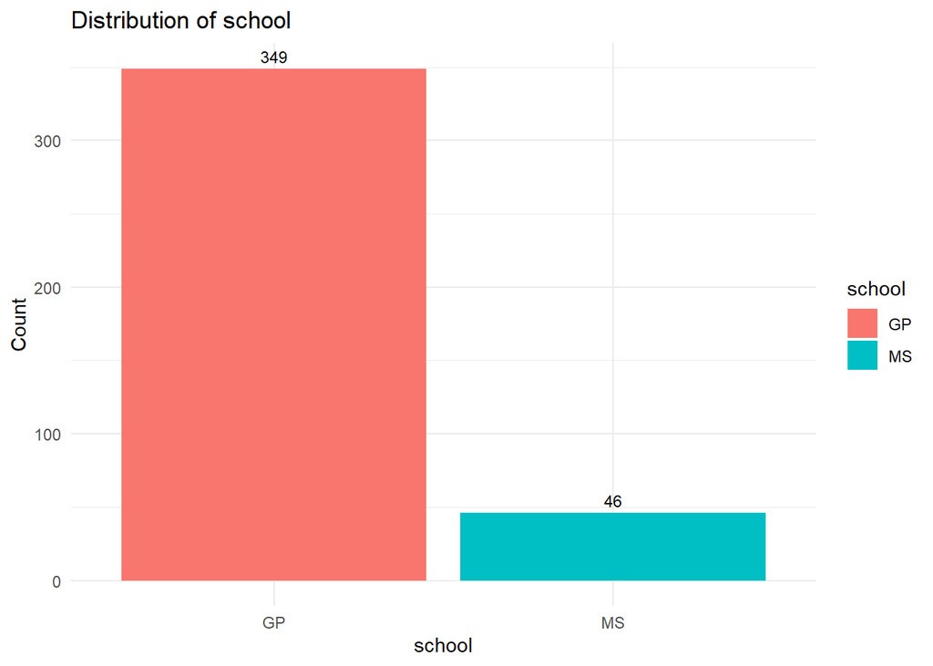

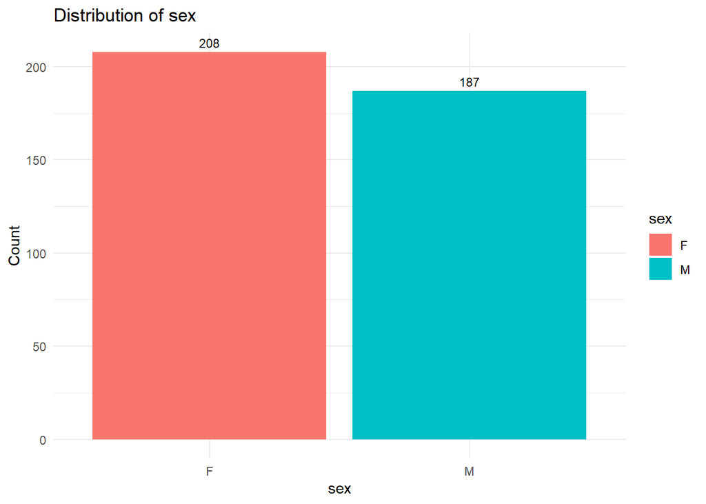

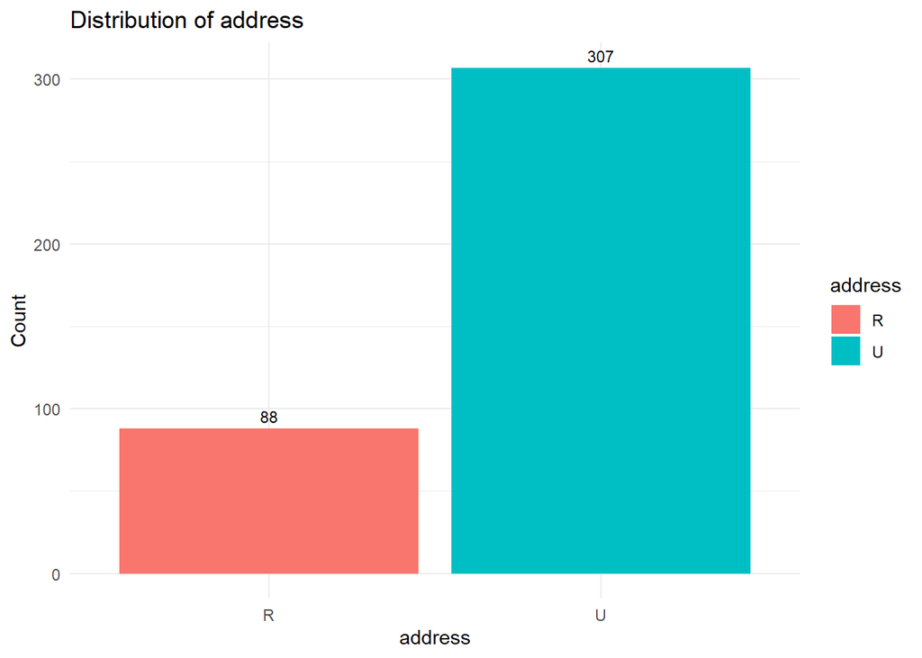

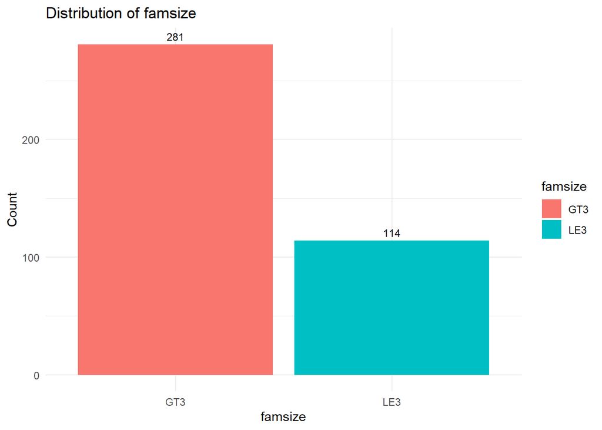

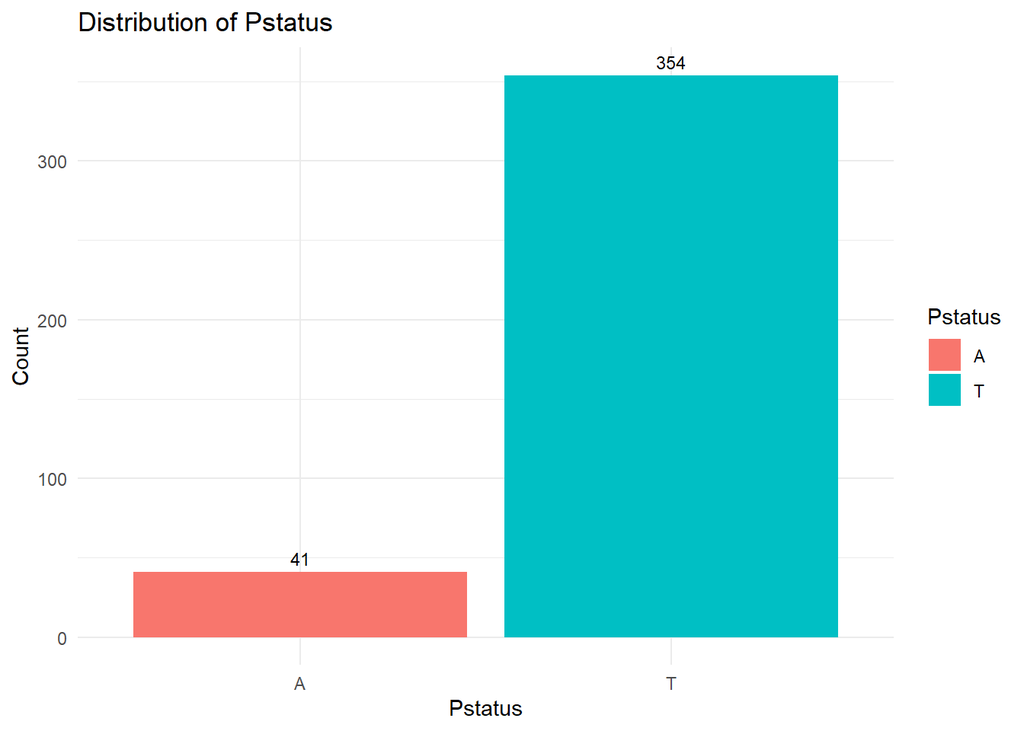

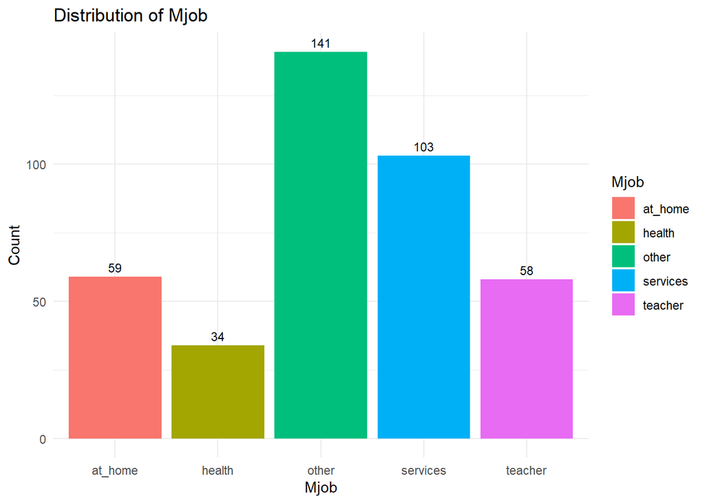

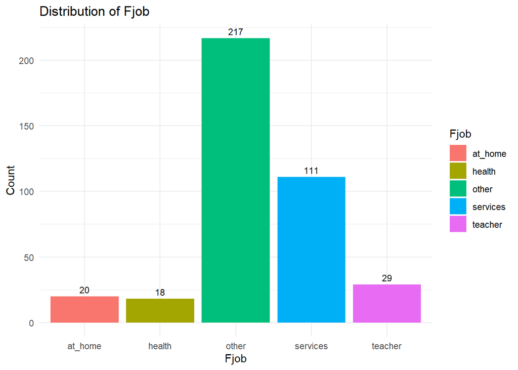

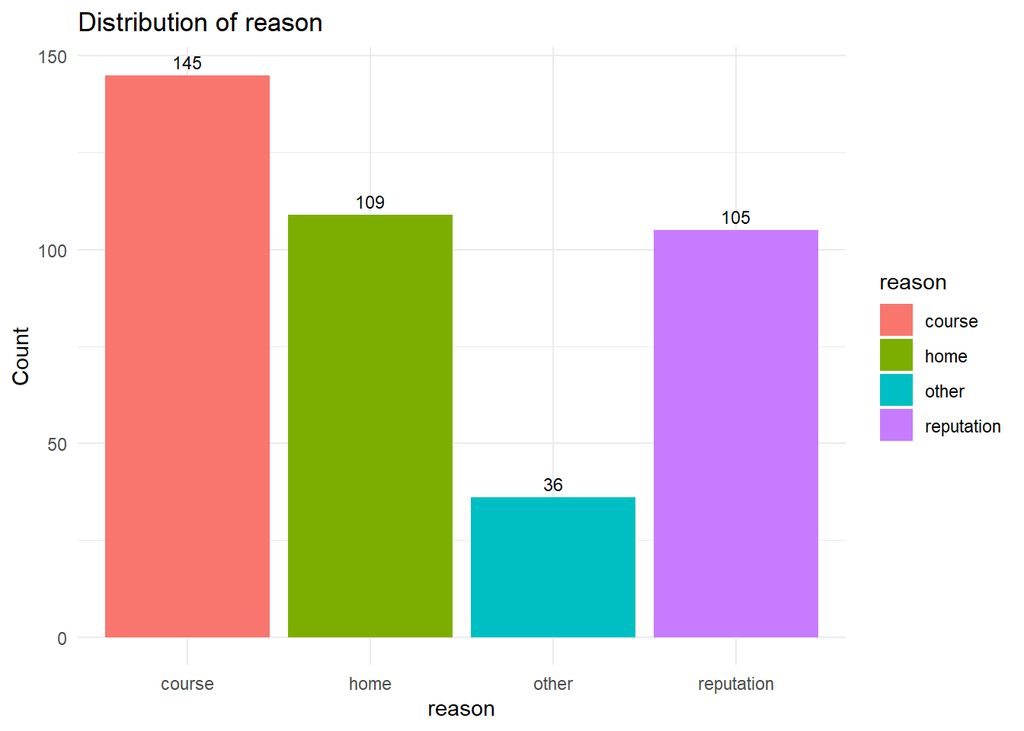

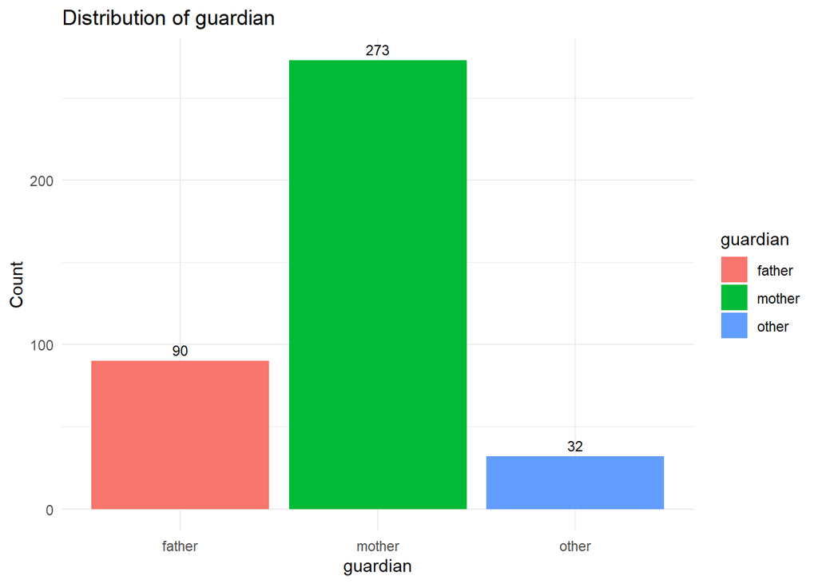

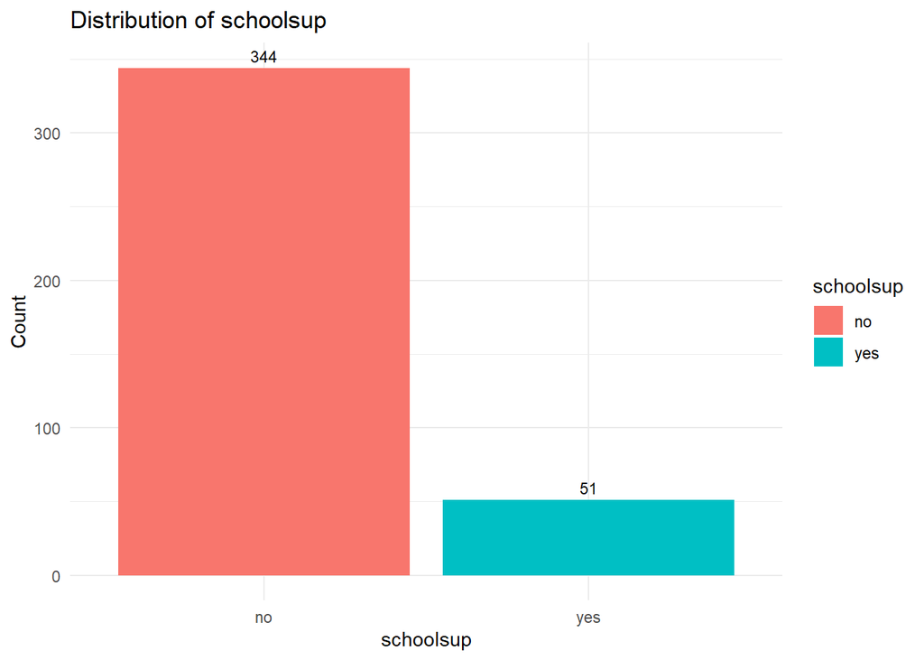

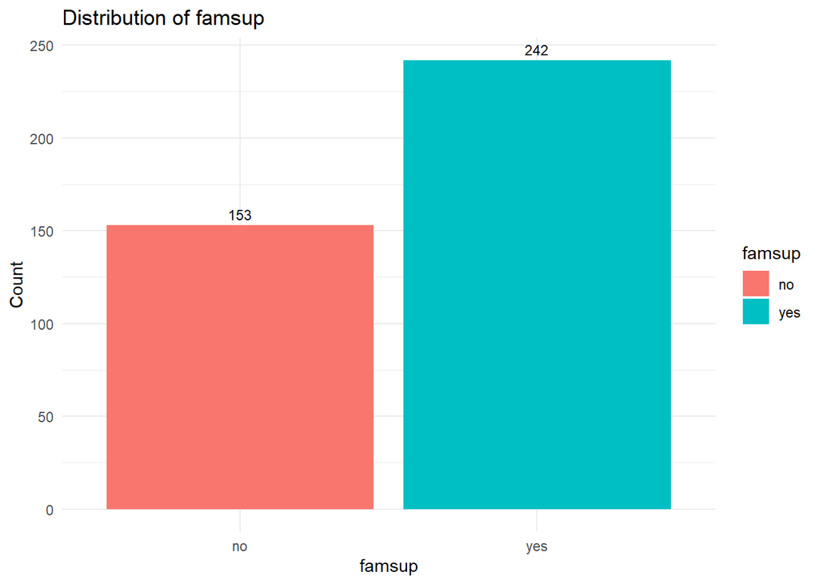

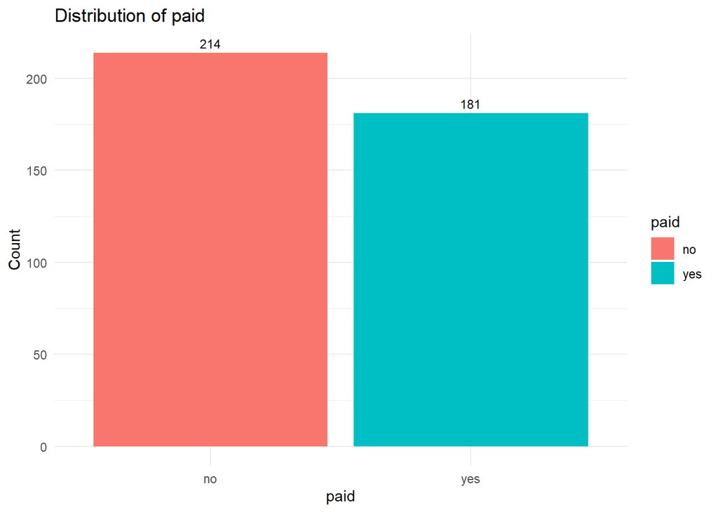

[5 more figures not shown]

```r
# Load the necessary libraries
library(ggplot2)

# Categorical variables
categorical_vars <- c("school", "sex", "address", "famsize", "Pstatus", "Mjob", "Fjob", "reason","guardian", "schoolsup", "famsup", "paid", "activities", "nursery", "higher", "internet", "romantic")

for (var in categorical_vars) {
  p <- ggplot(student_mat, aes_string(x = var, fill = var)) +
    geom_bar(stat = "count") +
    geom_text(stat = "count", aes(label = ..count..), vjust = -0.5, size = 3) +
    labs(title = paste("Distribution of", var),
         x = var,
         y = "Count") +
    theme_minimal()

  print(p)
}
```

**Interpretation of the Bar Charts:**

**DISTRIBUTION OF SCHOOL:**

The dataset contains students from two schools: “GP” (Gabriel Pereira) and “MS” (Mousinho da Silveira). The majority of students belong to the “GP” school (349 students), while a smaller portion belongs to the “MS” school (46 students).

**DISTRIBUTION OF SEX:**

The dataset includes both male and female students. The number of female students (208) is slightly higher than the number of male students (187).

**DISTRIBUTION OF ADDRESS:**

The students’ addresses are categorized into “R” (rural) and “U” (urban) regions. The majority of students reside in urban areas (307 students), while a smaller number reside in rural areas (88 students).

**DISTRIBUTION OF FAMSIZE (Family Size):**

The dataset includes families of different sizes categorized as “GT3” (greater than 3) and “LE3” (less than or equal to 3). The majority of students come from families with more than 3 members (GT3, 281 students), while a smaller number come from families with 3 or fewer members (LE3, 114 students).

**DISTRIBUTION OF PSTATUS (Parent’s cohabitation status):**

The dataset includes students with parents who are either “A” (apart) or “T” (together). The majority of students have parents who are living together (T, 354 students), while a smaller number have parents who are living apart (A, 41 students).

**DISTRIBUTION OF GUARDIAN (Student’s Guardian):**

The dataset indicates three types of guardians: “father,” “mother,” and “other.” The majority of students have their mothers as guardians (273 students), followed by fathers (90 students), and a smaller number have other guardians (32 students).

**DISTRIBUTION OF SCHOOLSUP (Extra Educational Support):**

Students are categorized into “no” and “yes” based on whether they receive extra educational support. Most students do not receive extra educational support (344 students), while a smaller number receive such support (51 students).

**DISTRIBUTION OF FAMSUP (Family Educational Support):**

Students are categorized into “no” and “yes” based on whether they receive family educational support. A higher number of students receive family educational support (242 students) compared to those who do not (153 students).

**DISTRIBUTION OF PAID (Extra Paid Classes Within the Course Subject):**

Students are categorized into “no” and “yes” based on whether they take extra paid classes within the course subject. The number of students taking extra paid classes is relatively lower (181 students) compared to those who do not (214 students).

**DISTRIBUTION OF ACTIVITIES (Extracurricular Activities):**

Students are categorized into “no” and “yes” based on whether they participate in extracurricular activities. The number of students participating in extracurricular activities is almost equal to those who do not.

**DISTRIBUTION OF NURSERY (Attended Nursery School):**

Students are categorized into “no” and “yes” based on whether they attended nursery school before primary school. The majority of students attended nursery school (314 students), while a smaller number did not (81 students).

**DISTRIBUTION OF HIGHER (Wants to Take Higher Education):**

Students are categorized into “no” and “yes” based on whether they want to pursue higher education. The majority of students have a desire to pursue higher education (375 students), while a few students do not (20 students).

**DISTRIBUTION OF INTERNET (Internet Access at Home):**

Students are categorized into “no” and “yes” based on whether they have internet access at home. The majority of students have internet access at home (329 students), while a smaller number do not (66 students).

**DISTRIBUTION OF ROMANTIC (In a Romantic Relationship):**

Students are categorized into “no” and “yes” based on whether they are in a romantic relationship. The majority of students are not in a romantic relationship (263 students), while a smaller number are (132 students).

#### Generating the visualizations for the Discrete Numerical variables.

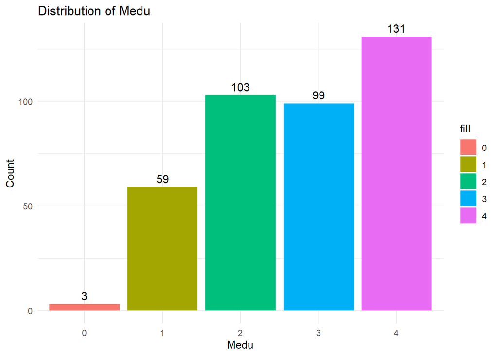

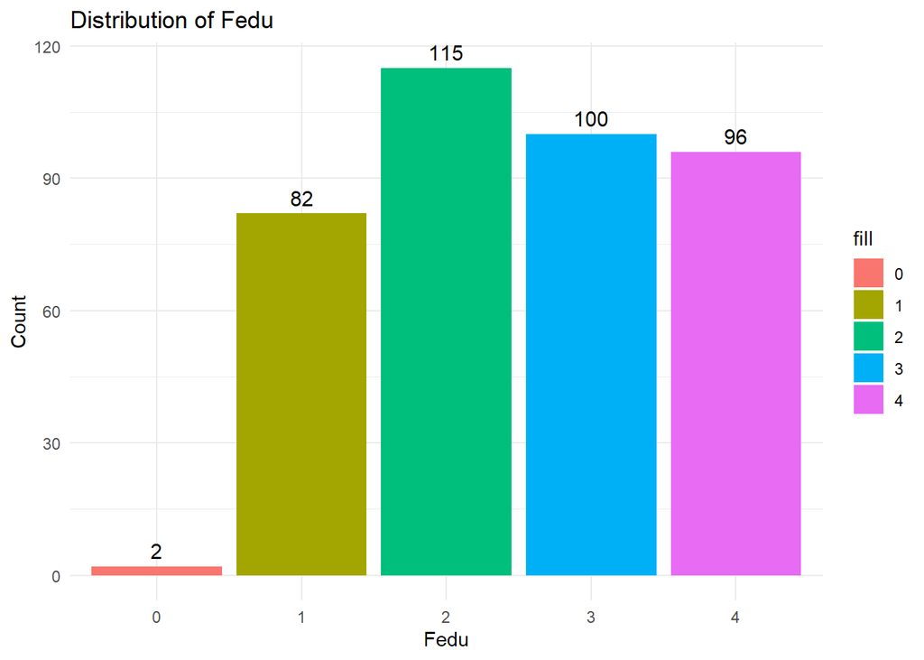

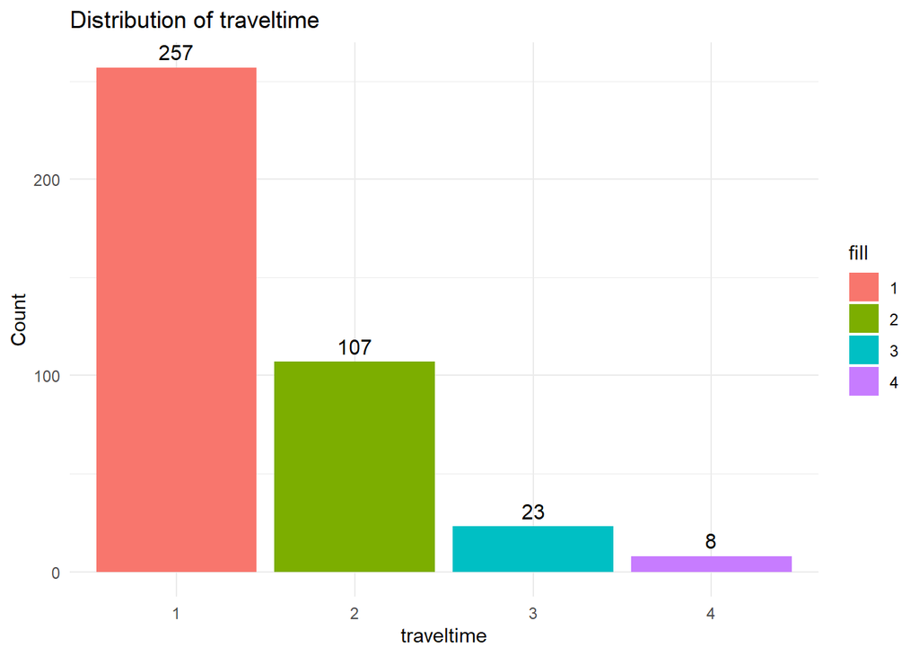

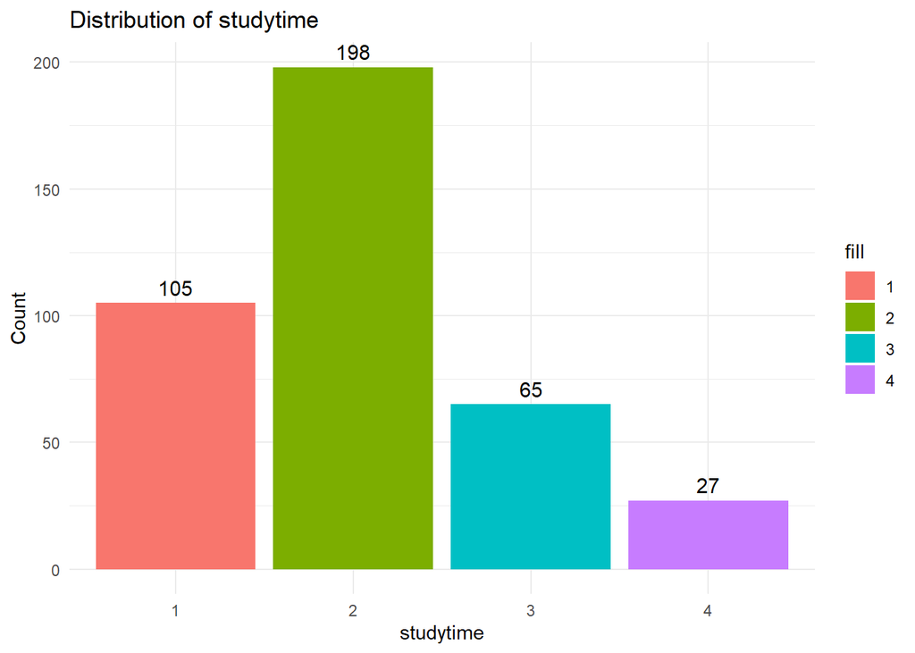

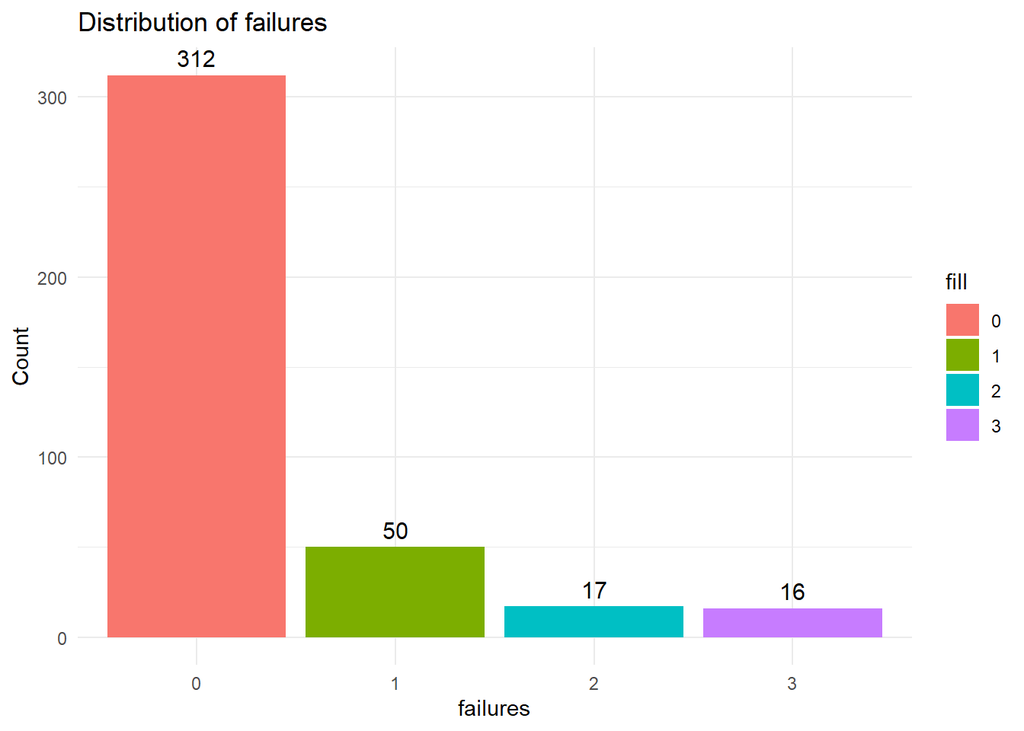

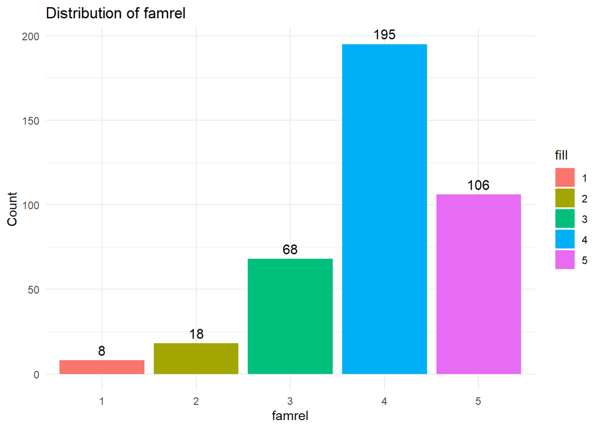

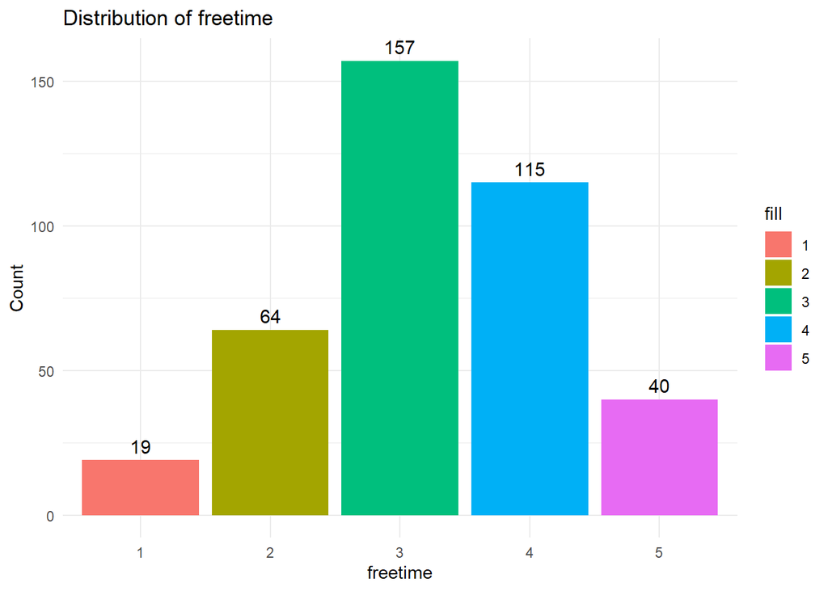

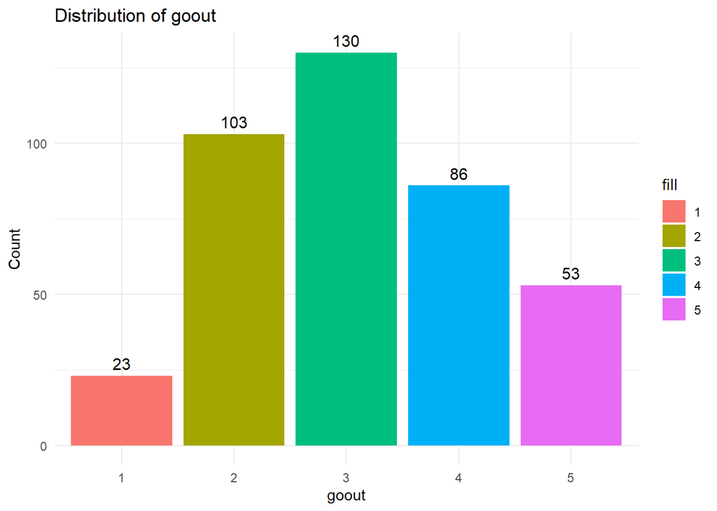

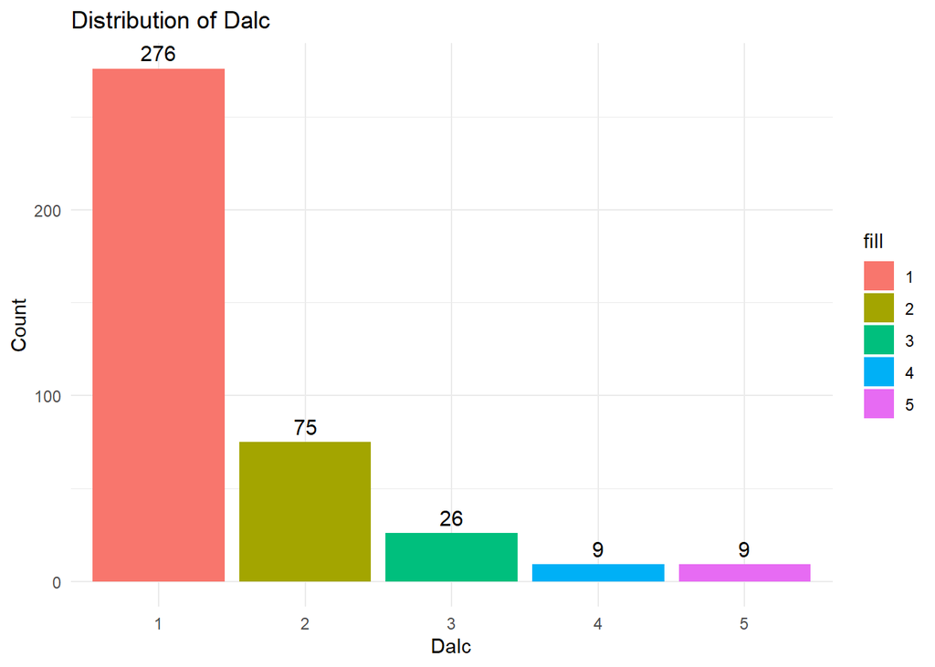

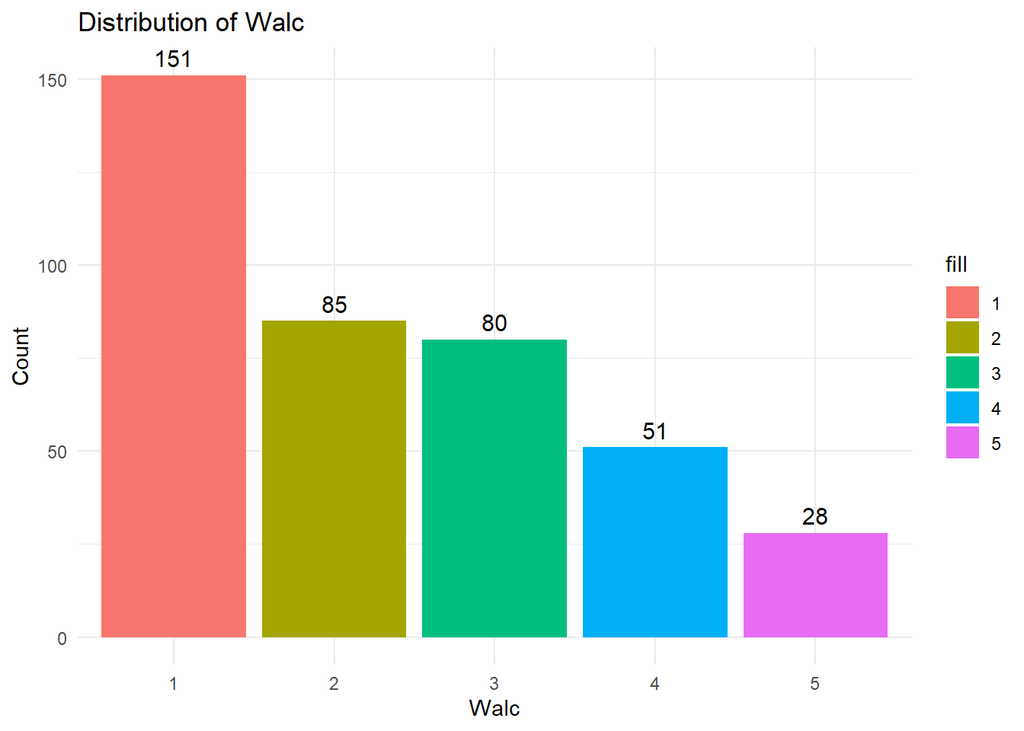

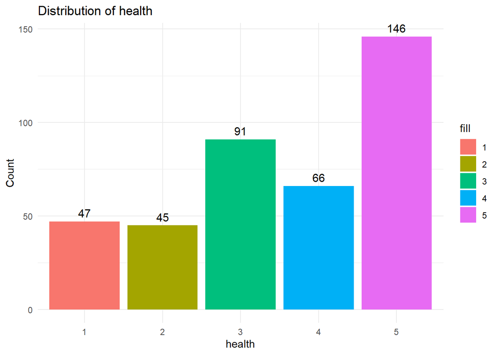

```r
# Load the necessary library
library(ggplot2)

# Discrete numerical variables
discrete_numeric_vars <- c("Medu", "Fedu", "traveltime", "studytime", "failures", "famrel",
                           "freetime", "goout", "Dalc", "Walc", "health")

# Loop through each discrete numerical variable
for (var in discrete_numeric_vars) {
  # Create a bar plot
  p <- ggplot(student_mat, aes_string(x = as.factor(student_mat[[var]]), fill = as.factor(student_mat[[var]]))) +
    geom_bar() +
    labs(title = paste("Distribution of", var),
         x = var,
         y = "Count") +
    theme_minimal() +
    # Add text annotations for count
    geom_text(stat='count', aes(label=..count..), vjust=-0.5, size=4)

  # Print the plot
  print(p)
}
```